# 21_ESmoothing_Trended_Seasonal

```r
library(fpp3)
```

# References

1. Hyndman, R.J., & Athanasopoulos, G., 2021. *Forecasting: principles and practice*. 3rd edition.
2. Fable package documentation
- https://fable.tidyverts.org/index.html
- https://fable.tidyverts.org/articles/fable.html

# Note

This notebook is not original material, but rather based on ref. 1 with notes expanding on some of the concepts contained in the book.

# **Motivation**

Extension of Holt’s Method to capture seasonality. It comprises the **forecast equation** and **three smoothing equations** for the following paramentrs

- The **level** $l_t$ (parameter $\alpha$)
- The **trend** $b_t$ (parameter $\beta*$)
- The **seasonal component** $s_t$ (parameter $\gamma$)

The symbol $m$ is the **length of the seasonality period**, i.e., the duration of seasons a seasonal period. For quarterly data $m = 4$, for monthly data $m= 12$, etc… etc…

# Additive vs Multiplicative:

There are two variations of the method.

- The **additive** method is preferred when the seasonal variations **do not change proportionally to the level of the series.**
  - **Seasonal component** expressed in **absolute terms** in the **scale of the observed series**
  - Level equation: the series is **seasonally adjusted** by **subtracting the seasonal component**
  - Within a year the seasonal component will add up to approximately zero (for further details see the lessons on classical decomposition).
- The **multiplicative method** is preferred when the **seasonal variations change proportionally to the level of the series**.
  - **Seasonal component** expressed in relative terms (percentages)
  - Level equation: the series is **seasonally adjusted** by **dividing through by the seasonal component**.
  - Within a year the seasonal component will sum up to approximately $m$.

# Holt’s Winters’ additive method:

**Component form equations**:

$$\begin{align*}
\hat{y}_{t+h|t} &= \ell_{t} + hb_{t} + s_{t+h-m(k+1)} \\
\ell_{t} &= \alpha(y_{t} - s_{t-m}) + (1 - \alpha)(\ell_{t-1} + b_{t-1})\\
b_{t} &= \beta^*(\ell_{t} - \ell_{t-1}) + (1 - \beta^*)b_{t-1}\\
s_{t} &= \gamma (y_{t}-\ell_{t-1}-b_{t-1}) + (1-\gamma)s_{t-m},
\end{align*}$$

- $k = int(\frac{h-1}{m})$, where $int()$ is the function *integer part*. In other words, $k$ is the number of periods between the current forecast horizon $h$ and the latest available observation.
  - when computing fitted values $h = 1$ (one-step ahead forecasts on the training data). Therefore $k = 0$ when computing the fitted values. This results in a summand $s_{t+h-m}$ on the level equation when computing fitted values, indicating that the seasonal component is borrowed from the previous seasonal period.
  - when computing forecasts:
    - for $1 \leq h \leq m$ we have $\frac{h-1}{m} < 1$ and thus $k = 0$.
    - for $m+1 \leq h$ we have $\frac{h-1}{m} \geq 1$ and this $k \geq 1$.
    - Thus the index $k$ ensures that the estimates of the seasonal component used for forecasting come from the final year of the observations.
- **Level equation:** weighted average between the seasonally adjusted observation and the non-seasonal forecast

$$\begin{align*}
l_{t} &= \alpha\underbrace{(y_{t} - s_{t-m})}_\textrm{seasonally adjusted observation} + (1 - \alpha)\underbrace{(\ell_{t-1} + b_{t-1})}_\textrm{non seasonal forecast}\\
\end{align*}$$

- **Trend equation**: identical to Holt’s linear method
- **The seasonal equation**: weighted average between the current seasonal index and the seasonal index of the same observation for last year ($m$ periods ago)

$$\begin{align*}
s_{t} &= \underbrace{\gamma (y_{t}-\ell_{t-1}-b_{t-1})}_\textrm{current seasonal index} + \underbrace{(1-\gamma)s_{t-m}}_\textrm{seasonal index of the same season, last year}
\end{align*}$$

# Holt Winter’s multiplicative Method:

The component form of the multiplicative method is:

$$\begin{align*}
\hat{y}_{t+h|t} &= (\ell_{t} + hb_{t})s_{t+h-m(k+1)} \\
\ell_{t} &= \alpha \frac{y_{t}}{s_{t-m}} + (1 - \alpha)(\ell_{t-1} + b_{t-1})\\
b_{t} &= \beta^*(\ell_{t}-\ell_{t-1}) + (1 - \beta^*)b_{t-1} \\
s_{t} &= \gamma \frac{y_{t}}{(\ell_{t-1} + b_{t-1})} + (1 - \gamma)s_{t-m}.
\end{align*}$$

The difference with the additive method is that the adjusted seasonal component is computed by dividing the observations by the seasonal component rather than by their difference.

# Example: Domestic overnight trips in Australia

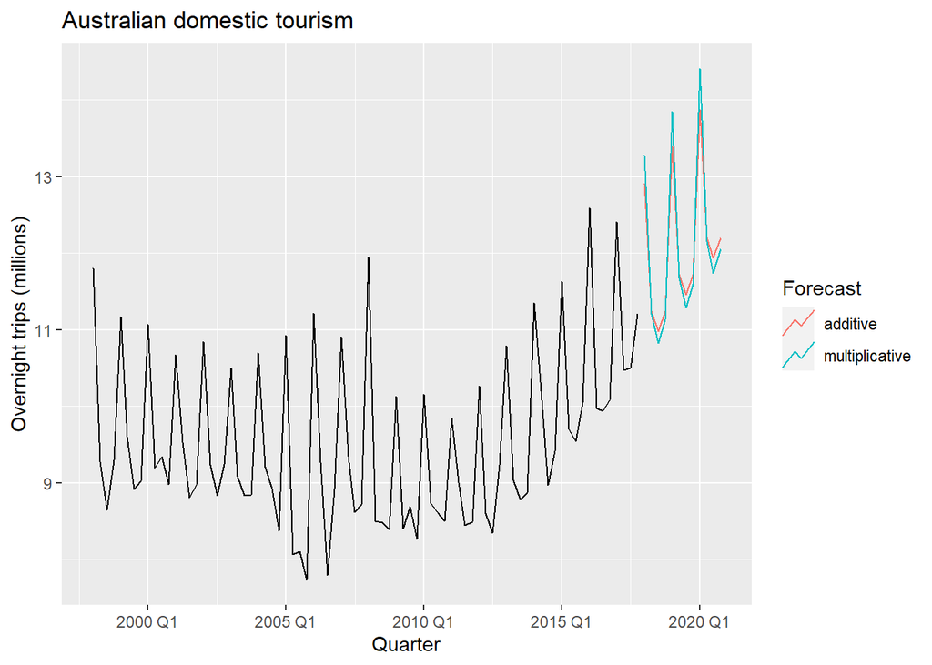

```r
# Filter data
aus_holidays <- tourism %>%
  filter(Purpose == "Holiday") %>%
  summarise(Trips = sum(Trips)/1e3)

# Fit the models: Generative and multiplicative seasonality
fit <- aus_holidays %>%
  model(
    additive = ETS(Trips ~ error("A") + trend("A") +
                                                season("A")),
    multiplicative = ETS(Trips ~ error("M") + trend("A") +
                                                season("M"))
  )

# Generate forecasts
fc <- fit %>% forecast(h = "3 years")

# Plot the forecasts
fc %>%
  autoplot(aus_holidays, level = NULL) +
  labs(title="Australian domestic tourism",
       y="Overnight trips (millions)") +
  guides(colour = guide_legend(title = "Forecast"))
```

```r
aus_holidays %>%
  model(
    classical_decomposition(Trips, type = "multiplicative")
  ) %>%
  components()
```

```
# A dable: 80 x 7 [1Q]
# Key:     .model [1]
# :        Trips = trend * seasonal * random
   .model                      Quarter Trips trend seasonal random season_adjust
   <chr>                         <qtr> <dbl> <dbl>    <dbl>  <dbl>         <dbl>
 1 "classical_decomposition(T~ 1998 Q1 11.8  NA       1.16  NA             10.2
 2 "classical_decomposition(T~ 1998 Q2  9.28 NA       0.970 NA              9.57
 3 "classical_decomposition(T~ 1998 Q3  8.64  9.68    0.928  0.962          9.31
 4 "classical_decomposition(T~ 1998 Q4  9.30  9.64    0.942  1.02           9.87
 5 "classical_decomposition(T~ 1999 Q1 11.2   9.71    1.16   0.991          9.63
 6 "classical_decomposition(T~ 1999 Q2  9.61  9.71    0.970  1.02           9.91
 7 "classical_decomposition(T~ 1999 Q3  8.91  9.67    0.928  0.994          9.61
 8 "classical_decomposition(T~ 1999 Q4  9.03  9.60    0.942  0.998          9.58
 9 "classical_decomposition(T~ 2000 Q1 11.1   9.61    1.16   0.993          9.54
10 "classical_decomposition(T~ 2000 Q2  9.20  9.65    0.970  0.982          9.48
# ... with 70 more rows
```

Fitting these models requires an iterative process very similar to that outlined for trended methods in the previous session (the difference being that now there is an additional equation and smoothing parameter for the seasonal component. Please refer to the flowchart on the lesson on trended methods for a better understanding of the process.

In the table below, **Holt-Winters’ method with additive seasonality** is developed in more detail. For that, the following initial values

- The level $l_t$ of the series - estimated as the average of the observations in the first period (first four observations)
- The slope of the series $b_t$ - since the series send to have no trend within the first season, we estimate it as 0.
- Estimates of the first 4 seasonal components - in this case taken as the first four elements of the seasonal component of a classical decomposition (additive) of the series.

| Quarter | Time | Observation | Level | Slope | Season | Forecast |
| --- | --- | --- | --- | --- | --- | --- |
|  | t | $y_t$ | $l_t$ | $b_t$ | $s_t$ | $\hat{y}_{t+1\|t}$ |
| 1997 Q1 | 0 |  |  |  | 1.5 |  |
| 1997 Q2 | 1 |  |  |  | -0.3 |  |
| 1997 Q3 | 2 |  |  |  | -0.7 |  |
| 1997 Q4 | 3 |  | 9.8 | 0.0 | -0.5 |  |
| 1998 Q1 | 4 | 11.8 | 9.9 | 0.0 | 1.5 | 11.3 |
| 1998 Q2 | 5 | 9.3 | 9.9 | 0.0 | -0.3 | 9.7 |
| 1998 Q3 | 6 | 8.6 | 9.7 | -0.0 | -0.7 | 9.2 |
| 1998 Q4 | 7 | 9.3 | 9.8 | 0.0 | -0.5 | 9.2 |
|  | … | … | … | … | … | … |
| 2017 Q1 | 80 | 12.4 | 10.9 | 0.1 | 1.5 | 12.3 |
| 2017 Q2 | 81 | 10.5 | 10.9 | 0.1 | -0.3 | 10.7 |
| 2017 Q3 | 82 | 10.5 | 11.0 | 0.1 | -0.7 | 10.3 |
| 2017 Q4 | 83 | 11.2 | 11.3 | 0.1 | -0.5 | 10.6 |
|  | $h$ |  |  |  |  | $\hat{y}_{T+h}$ |
| 2018 Q1 | 1 |  |  |  |  | 12.9 |
| 2018 Q2 | 2 |  |  |  |  | 11.2 |
| 2018 Q3 | 3 |  |  |  |  | 11.0 |
| 2018 Q4 | 4 |  |  |  |  | 11.2 |
| 2019 Q1 | 5 |  |  |  |  | 13.4 |
| 2019 Q2 | 6 |  |  |  |  | 11.7 |
| 2019 Q3 | 7 |  |  |  |  | 11.5 |
| 2019 Q4 | 8 |  |  |  |  | 11.7 |
| 2020 Q1 | 9 |  |  |  |  | 13.9 |
| 2020 Q2 | 10 |  |  |  |  | 12.2 |
| 2020 Q3 | 11 |  |  |  |  | 11.9 |
| 2020 Q4 | 12 |  |  |  |  | 12.2 |

The folloing table does the same but following a multiplicative approach:

- The level $l_t$ of the series - estimated as the average of the observations in the first period (first four observations)
- The slope of the series $b_t$ - since the series send to have no trend within the first season, we estimate it as 0.
- Estimates of the first 4 seasonal components - in this case taken as the first four elements of the seasonal component of a classical decomposition (multiplicative) of the series.

| Quarter | Time | Observation | Level | Slope | Season | Forecast |
| --- | --- | --- | --- | --- | --- | --- |
|  | $t$ | $y_t$ | $l_t%$ | $b_t$ | $s_t$ | $y_{t+1}$ |
| 1997 Q1 | 0 |  |  |  | 1.2 |  |
| 1997 Q2 | 1 |  |  |  | 1.0 |  |
| 1997 Q3 | 2 |  |  |  | 0.9 |  |
| 1997 Q4 | 3 |  | 10.0 | -0.0 | 0.9 |  |
| 1998 Q1 | 4 | 11.8 | 10.0 | -0.0 | 1.2 | 11.6 |
| 1998 Q2 | 5 | 9.3 | 9.9 | -0.0 | 1.0 | 9.7 |
| 1998 Q3 | 6 | 8.6 | 9.8 | -0.0 | 0.9 | 9.2 |
| 1998 Q4 | 7 | 9.3 | 9.8 | -0.0 | 0.9 | 9.2 |
|  | … | … | … | … | … | … |
| 2017 Q1 | 80 | 12.4 | 10.8 | 0.1 | 1.2 | 12.6 |
| 2017 Q2 | 81 | 10.5 | 10.9 | 0.1 | 1.0 | 10.6 |
| 2017 Q3 | 82 | 10.5 | 11.1 | 0.1 | 0.9 | 10.2 |
| 2017 Q4 | 83 | 11.2 | 11.3 | 0.1 | 0.9 | 10.5 |
|  | $h$ |  |  |  |  | $\hat{y}_{T+h\vert T}$ |
| 2018 Q1 | 1 |  |  |  |  | 13.3 |
| 2018 Q2 | 2 |  |  |  |  | 11.2 |
| 2018 Q3 | 3 |  |  |  |  | 10.8 |
| 2018 Q4 | 4 |  |  |  |  | 11.1 |
| 2019 Q1 | 5 |  |  |  |  | 13.8 |
| 2019 Q2 | 6 |  |  |  |  | 11.7 |
| 2019 Q3 | 7 |  |  |  |  | 11.3 |
| 2019 Q4 | 8 |  |  |  |  | 11.6 |
| 2020 Q1 | 9 |  |  |  |  | 14.4 |
| 2020 Q2 | 10 |  |  |  |  | 12.2 |
| 2020 Q3 | 11 |  |  |  |  | 11.7 |
| 2020 Q4 | 12 |  |  |  |  | 12.1 |

# Homework 2: reproduce these tables (excels provided by professor)

```r
fit
```

```
# A mable: 1 x 2
      additive multiplicative
       <model>        <model>
1 <ETS(A,A,A)>   <ETS(M,A,M)>
```

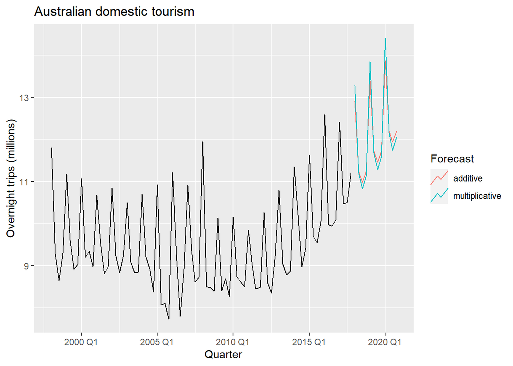

```r
aus_holidays <- tourism %>%
  filter(Purpose == "Holiday") %>%
  summarise(Trips = sum(Trips)/1e3)
fit <- aus_holidays %>%
  model(
    additive = ETS(Trips ~ error("A") + trend("A") +
                                                season("A")),
    multiplicative = ETS(Trips ~ error("M") + trend("A") +
                                                season("M"))
  )
fc <- fit %>% forecast(h = "3 years")
fc %>%
  autoplot(aus_holidays, level = NULL) +
  labs(title="Australian domestic tourism",
       y="Overnight trips (millions)") +
  guides(colour = guide_legend(title = "Forecast"))
```

```r
fit %>% accuracy() %>% select(.model, RMSE) %>% mutate(RMSE = round(RMSE, 4))
```

```
# A tibble: 2 x 2
  .model          RMSE
  <chr>          <dbl>
1 additive       0.417
2 multiplicative 0.412
```

In this case the multiplicative scheme seems to fit the data slightly better, although the difference is not substantial.

We can plot the components of the resulting ETS decomposition (fitted values)

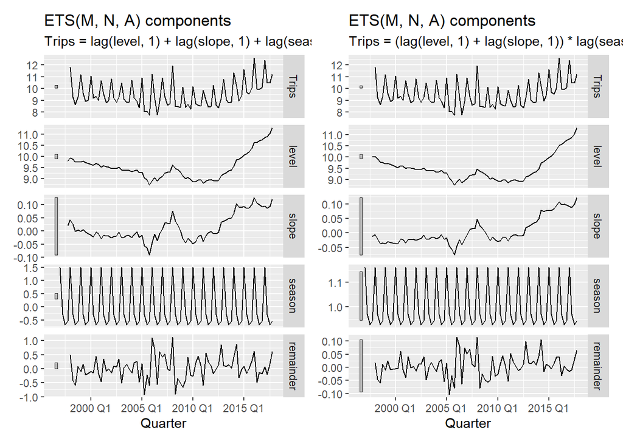

```r
fig_additive <- fit %>%
  select("additive") %>%
  components() %>%
  autoplot() +
  labs(title = "ETS(M, N, A) components")
  # facet_wrap(.model)

fig_multiplicative <- fit %>%
  select("multiplicative") %>%
  components() %>%
  autoplot() +
  labs(title = "ETS(M, N, A) components")
  # facet_wrap(.model)

# Used patchwork library syntax to organize plots
fig_additive + fig_multiplicative
```

- The small value of $\gamma$ for the multiplicative model means that the seasonal component barely changes over time.
- The small value of $\beta*$ means that the slope component barely changes over time.

# Holt-Winters damped method

This is often the singlemost accurate method for seasonal data. Often the variant with a **damped trend** and **multiplicative seasonality** works very well:

$$\begin{align*}
\hat{y}_{t+h|t} &= \left[\ell_{t} + (\phi+\phi^2 + \dots + \phi^{h})b_{t}\right]s_{t+h-m(k+1)} \\
\ell_{t} &= \alpha(y_{t} / s_{t-m}) + (1 - \alpha)(\ell_{t-1} + \phi b_{t-1})\\
b_{t} &= \beta^*(\ell_{t} - \ell_{t-1}) + (1 - \beta^*)\phi b_{t-1} \\
s_{t} &= \gamma \frac{y_{t}}{(\ell_{t-1} + \phi b_{t-1})} + (1 - \gamma)s_{t-m}.
\end{align*}$$

## Example: daily data

Holt-Winters method can be used for daily type of data.

- m = 7 (seasonal period, 1 week)

```r
sth_cross_ped <- pedestrian %>%
  filter(Date >= "2016-07-01",
         Sensor == "Southern Cross Station") %>%
  index_by(Date) %>%
  summarise(Count = sum(Count)/1000)

sth_cross_ped
```

```
# A tsibble: 184 x 2 [1D]
   Date       Count
   <date>     <dbl>
 1 2016-07-01 17.6
 2 2016-07-02  2.52
 3 2016-07-03  1.73
 4 2016-07-04 17.3
 5 2016-07-05 16.5
 6 2016-07-06 16.8
 7 2016-07-07 17.0
 8 2016-07-08 17.2
 9 2016-07-09  3.21
10 2016-07-10  1.75
# ... with 174 more rows
```

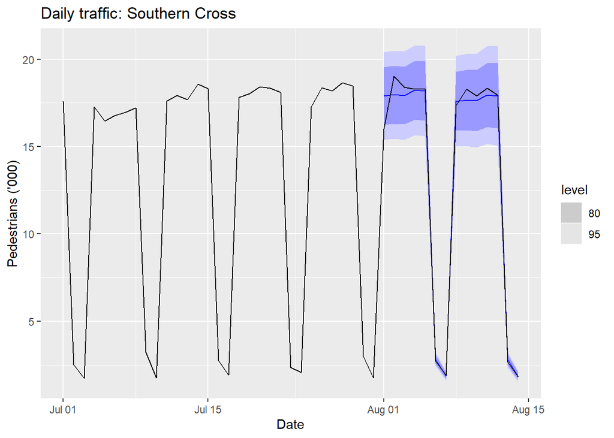

```r
fit <- sth_cross_ped %>%
  filter(Date <= "2016-07-31") %>%
  model(
    hw = ETS(Count ~ error("M") + trend("Ad") + season("M"))
  )

fc <- fit %>%
  forecast(h = "2 weeks")

fc %>%
  autoplot(sth_cross_ped %>% filter(Date <= "2016-08-14")) +
  labs(title = "Daily traffic: Southern Cross",
       y="Pedestrians ('000)")
```

The model has identified the weekly seasonal pattern and the increasing trend at the end of the data, and the forecasts are a close match to the test data.

# Homework 3

For this exercise use the quarterly number of arrivals to Australia from New Zealand, 1981 Q1 – 2012 Q3, from data set `aus_arrivals`.

```r
nz_arrivals <- aus_arrivals %>% filter(Origin == "NZ")
nz_arrivals
```

```
# A tsibble: 127 x 3 [1Q]
# Key:       Origin [1]
   Quarter Origin Arrivals
     <qtr> <chr>     <int>
 1 1981 Q1 NZ        49140
 2 1981 Q2 NZ        87467
 3 1981 Q3 NZ        85841
 4 1981 Q4 NZ        61882
 5 1982 Q1 NZ        42045
 6 1982 Q2 NZ        63081
 7 1982 Q3 NZ        73275
 8 1982 Q4 NZ        54808
 9 1983 Q1 NZ        41030
10 1983 Q2 NZ        56155
# ... with 117 more rows
```

1. Make a time plot of your data adjusting the grid to properly identify a yearly seasonality.
2. Create a training set that withholds the last two years of available data. Forecast the test set using an appropriate model for Holt-Winters’ multiplicative method.
3. Would you say that multiplicative seasonality is necessary?
4. Perform forecasts of up to a horizon of two years using the following models:
- an ETS model;
- an additive ETS model applied to a log transformed series;
- a Seasonal Na�ve method;
- an STL decomposition applied to the log transformed data followed by an ETS model applied to the seasonally adjusted (transformed) data.
5. Which method gives the best forecasts for a horizon h = 1? and for a horizon of h = 8?
6. Does the method pass the residuals test?
7. Compare the same four methods using time series cross-validation instead of using a training and test set. Do you come to the same conclusions?. The smallest dataset shall leave out 10 years of available data and the datasets shall increase in steps of 1 year.